# Health Inequalities in England: Deprivation and Life Expectancy Analysis

Usman Adamu

2026-04-19

## Introduction

Health inequalities remain one of the most persistent challenges facing public health in England. Life expectancy — a fundamental measure of population health — varies substantially across geographic areas and socioeconomic groups, reflecting deep-rooted structural inequalities in the social determinants of health. The relationship between deprivation and life expectancy has been extensively documented, with the Marmot Review establishing that life expectancy follows a social gradient: the more deprived the area, the shorter the lives of the people who live there (Marmot et al., 2010).

This report presents an epidemiological analysis of life expectancy trends and health inequalities in England using data from the Office for Health Inequalities and Disparities (OHID) Fingertips platform. The analysis examines national trends in life expectancy by sex, geographic variation across local authorities, the relationship between deprivation and life expectancy, and inequality in life expectancy between the most and least deprived areas.

### Research Questions

1. How has life expectancy changed in England between 2001 and 2024 for males and females?
2. Which local authorities have the highest and lowest life expectancy in England?
3. What is the geographic distribution of life expectancy across English local authorities?
4. Is there a statistically significant relationship between deprivation and life expectancy at local authority level?
5. Does the relationship between deprivation and life expectancy differ by sex?
6. How does inequality in life expectancy between the most and least deprived areas vary over time?
7. How does total life expectancy compare to healthy life expectancy, and how has this gap changed over time?

## Data and Methods

### Data Source

Data were obtained from the OHID Fingertips platform using the fingertipsR package in R. Four indicators were extracted at local authority level (Counties and Unitary Authorities from April 2023):

- **Life expectancy at birth** (Indicator 90366)
- **Healthy life expectancy at birth** (Indicator 90362)
- **Deprivation score — IMD 2019** (Indicator 93553)
- **Inequality in life expectancy at birth** (Indicator 92901)

### Data Loading and Preparation

## Results

### 1. National Life Expectancy Trend 2001–2024

The chart below shows how life expectancy at birth has changed in England over two decades, by sex.

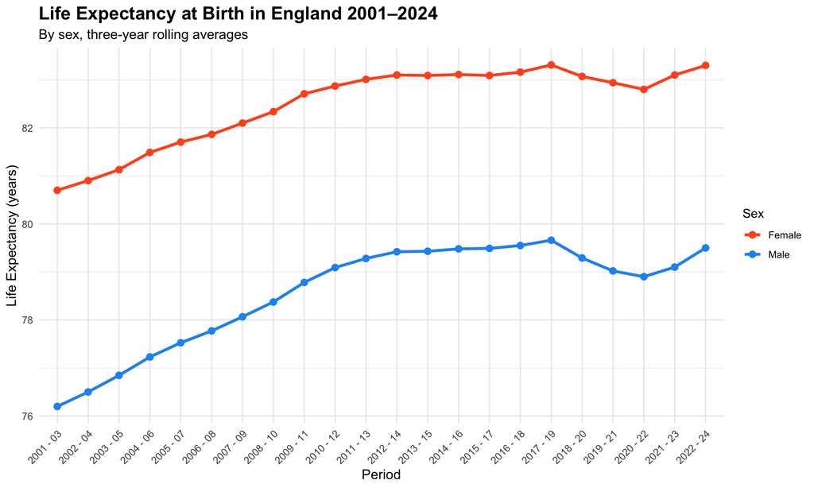

Life expectancy at birth in England increased steadily in both sexes between 2001-03 and 2012-14, consistent with sustained improvements in healthcare, medicines, vaccination coverage and socioeconomic conditions during this period.<sup>1,2</sup> However, this improvement stalled markedly after 2012-14 and remained largely static until 2018-20 — a pattern attributed in the literature to the effects of austerity policies, stagnating income growth and widening social inequalities following the 2008 financial crisis.<sup>3</sup> A sharp decline in life expectancy was observed in both sexes during 2019-21, most likely reflecting direct and indirect mortality attributable to the COVID-19 pandemic, including disruption to routine healthcare services and excess deaths among vulnerable populations.<sup>4</sup> Partial recovery was observed from 2021-23 onwards, though life expectancy had not returned to pre-pandemic trajectory by the most recent data point. Throughout the study period, female life expectancy consistently exceeded male life expectancy by approximately three to four years, consistent with established sex differentials in mortality in high-income countries.<sup>5</sup> It should be noted that a proportion of the observed increase in recorded life expectancy over time may partly reflect improvements in data completeness and reporting quality rather than true biological change alone.

### 2. Local Authority Variation in Life Expectancy

The charts below show the local authorities with the highest and lowest female life expectancy at birth in 2022-24.

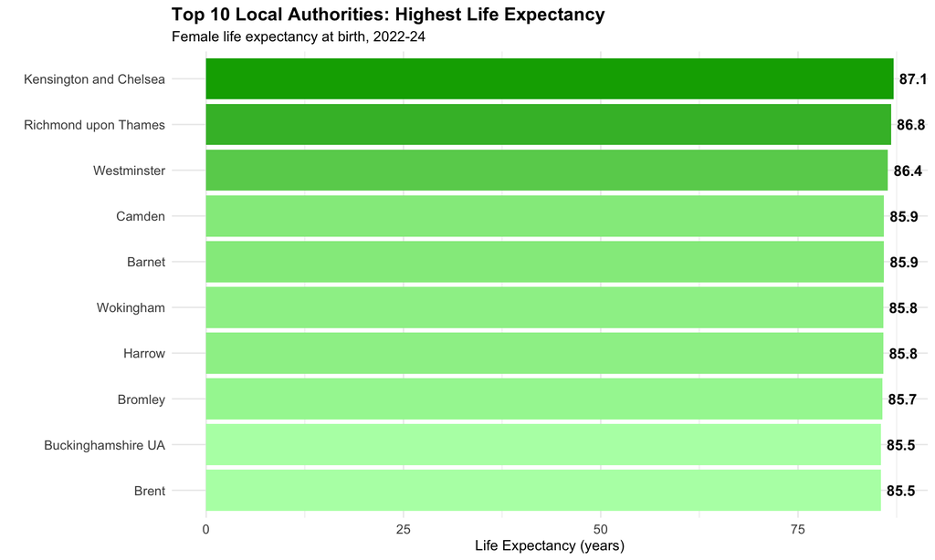

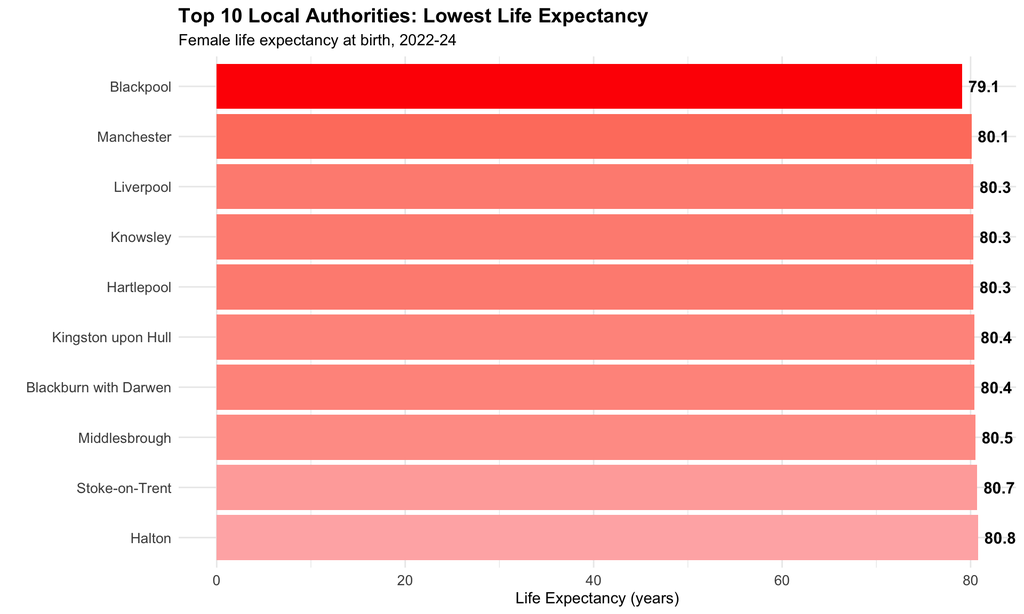

Considerable geographic variation in life expectancy exists across English local authorities, with a clear North-South gradient apparent in the 2022-24 data. Local authorities with the highest life expectancy are predominantly concentrated in southern England, while those with the lowest are located in northern regions — consistent with the established health inequality gradient documented extensively in the Marmot Reviews.<sup>3,6</sup> A female child born in Kensington and Chelsea would expect to live approximately eight years longer than her counterpart born in Blackpool — a gap that has persisted for decades and reflects entrenched socioeconomic inequality rather than individual circumstance.<sup>3,6</sup>

This geographic disparity reflects deep-rooted structural differences in the social determinants of health, including income, employment, housing quality, educational attainment and access to services — factors that cluster geographically and compound over time.<sup>3</sup> It should be noted that life expectancy alone provides an incomplete picture of population health. Healthy life expectancy — the number of years lived in good health — is an equally important measure, as it captures the quality as well as the quantity of life. Evidence consistently shows that the healthy life expectancy gap between deprived and affluent areas is substantially wider than the life expectancy gap alone, meaning that residents of the most deprived areas not only live shorter lives but spend a greater proportion of those lives in poor health.<sup>7</sup> This compounds the burden of deprivation and underscores the need for upstream policy interventions targeting the social determinants of health rather than downstream clinical treatment alone.

### 3. Geographic Distribution of Life Expectancy

The map below shows female life expectancy at birth across English local authorities in 2022-24.

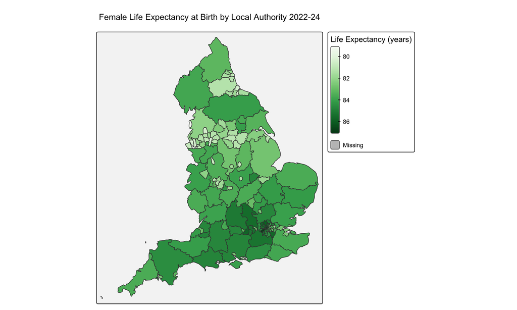

The choropleth map confirms the North-South gradient observed in the bar charts, with darker green shading — indicating higher life expectancy — concentrated predominantly in southern England, particularly in London, the South East and the South West. While isolated areas of higher life expectancy exist across the country, the overall spatial pattern is consistent with evidence identifying neighbourhood socioeconomic deprivation as a key driver of geographic inequalities in health outcomes in England.<sup>8</sup> Areas around Liverpool, Manchester and the North East show consistently lighter shading, reflecting persistently lower life expectancy in these regions. This geographic clustering of poor health outcomes in northern areas is not coincidental — it reflects decades of structural economic disadvantage, industrial decline and underinvestment in social infrastructure that have shaped the health of these populations over generations.<sup>3,6</sup>

### 4. Deprivation and Life Expectancy — Is There a Relationship?

The scatter plot below examines the relationship between neighbourhood deprivation and female life expectancy across English local authorities.

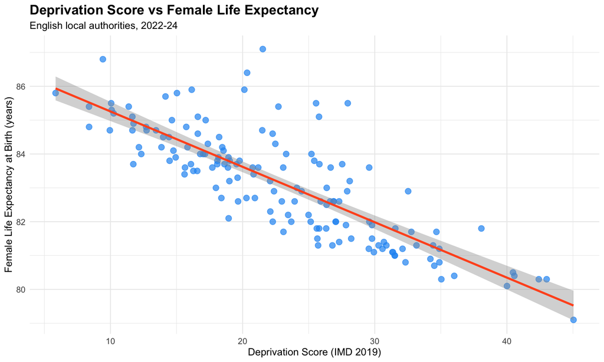

Linear regression confirmed a statistically significant negative relationship between deprivation score and female life expectancy across English local authorities (β = -0.16, p < 0.001, R² = 0.67). For every one unit increase in IMD deprivation score, female life expectancy decreased by approximately 0.16 years — equivalent to nearly two months of life lost per deprivation unit. Deprivation score alone explained 66.7% of the variance in female life expectancy across local authorities, representing an exceptionally strong association for a single predictor in ecological analysis. This finding is consistent with the foundational evidence from the Marmot Review establishing that life expectancy follows a social gradient across England, and with more recent evidence demonstrating that socioeconomic deprivation remains the dominant driver of geographic health inequalities.<sup>3,6</sup> The presence of a small number of outlying local authorities — those with higher or lower life expectancy than predicted by their deprivation score alone — suggests that additional factors including local health service quality, population composition, migration patterns and environmental conditions may modify the relationship between deprivation and mortality in specific localities. These findings are consistent with the established evidence that place-based deprivation is among the strongest determinants of population health in England.<sup>3,8</sup>

### 5. Deprivation and Life Expectancy by Sex

The scatter plots below examine whether the relationship between deprivation and life expectancy differs between males and females across English local authorities.

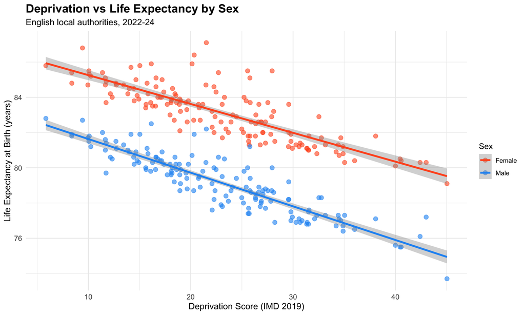

Regression modelling confirmed statistically significant negative associations between deprivation score and life expectancy in both sexes (both p < 0.001). However, the strength and magnitude of this relationship differed markedly between males and females. For males, deprivation score explained 79.8% of the variance in life expectancy (β = -0.191, R² = 0.798), compared to 66.7% for females (β = -0.163, R² = 0.667). This indicates that male life expectancy is more tightly determined by area-level deprivation than female life expectancy, and that males lose approximately 0.03 additional years of life per deprivation unit compared to females.<sup>3,6</sup>

The combined scatter plot illustrates these differential gradients clearly — while females maintain higher life expectancy than males at every level of deprivation, the male regression line is visibly steeper, indicating that the penalty of living in a deprived area is greater for men than for women. This pattern is consistent with evidence that men in deprived areas face disproportionately higher mortality from cardiovascular disease, suicide, alcohol-related conditions and occupational hazards — causes of death that are strongly socially patterned and more prevalent among men.<sup>9</sup> These findings reinforce the case for gender-sensitive public health strategies in deprived areas, targeting the specific causes of male excess mortality alongside broader deprivation reduction interventions.<sup>3,9</sup>

### 6. Inequality in Life Expectancy Across England

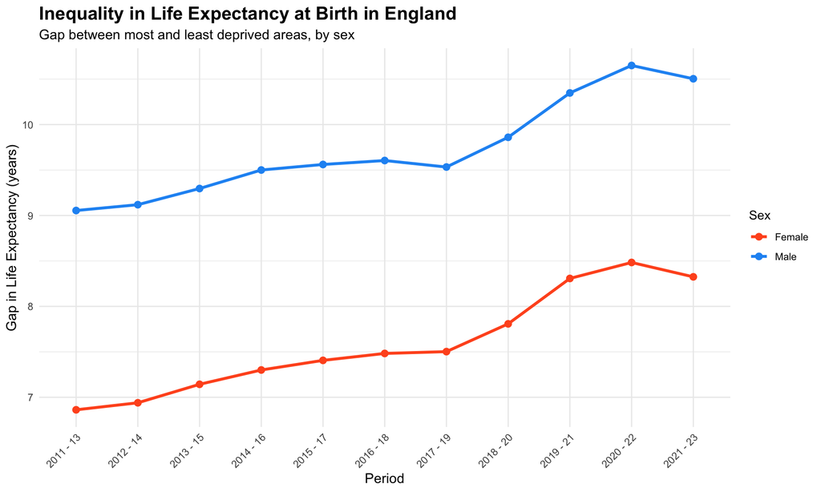

### 7. Life Expectancy vs Healthy Life Expectancy

The chart below compares total life expectancy with healthy life expectancy at birth in England over time, highlighting the years spent in poor health.

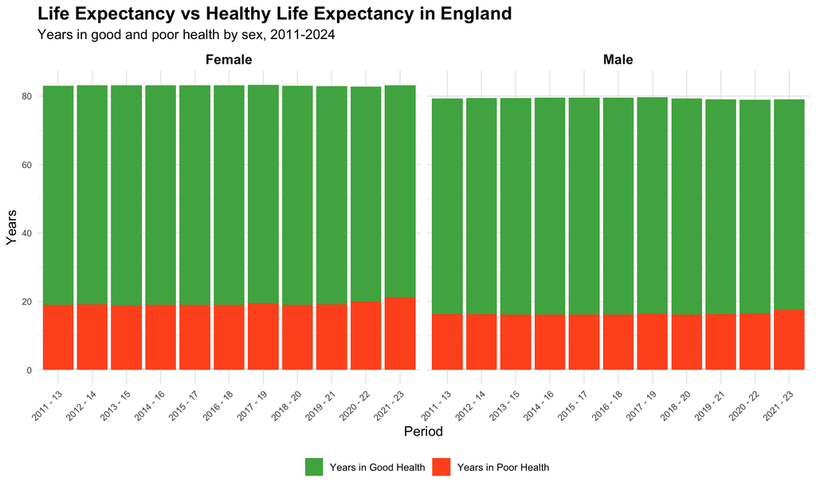

The stacked bar chart reveals a paradox at the heart of female longevity in England. Despite living approximately four years longer than males, females spend a greater absolute number of years in poor health — approximately 19 to 21 years compared to 16 to 17 years for males throughout the study period. This means that much of the female longevity advantage is spent in a state of ill health, disability or reduced functioning rather than in full health.<sup>7</sup>

The years spent in poor health remained remarkably stable across both sexes throughout the study period — the orange band shows virtually no change from 2011-13 to 2021-23 — indicating that while total life expectancy has fluctuated, the proportion of life spent in poor health has not improved meaningfully over more than a decade. A marginal increase in female years in poor health was observed in the most recent periods from 2020-22 onwards, consistent with evidence that the COVID-19 pandemic increased the burden of long-term conditions and disability, particularly among older women.<sup>4</sup>

These findings have significant implications for NHS planning and commissioning. The persistent gap between total and healthy life expectancy — representing approximately one fifth of all years lived in England — represents a substantial and largely unaddressed burden of chronic disease, disability and social care need. Policies focused solely on extending life expectancy without addressing the quality of those additional years risk increasing the demand for health and social care services without improving population wellbeing.<sup>3</sup> Healthy life expectancy should be adopted as a primary outcome measure in public health planning alongside total life expectancy.<sup>6</sup>

## Conclusion

### Key Findings

**1. Stalling and reversal of life expectancy gains**

Life expectancy in England increased steadily from 2001 to 2012-14 before stalling markedly — a pattern attributed to austerity policies and widening socioeconomic inequalities following the 2008 financial crisis.<sup>3</sup> The COVID-19 pandemic caused a sharp decline in life expectancy in both sexes from 2019-21, with only partial recovery observed by 2022-24. Female life expectancy consistently exceeded male life expectancy throughout the study period by approximately three to four years.<sup>5</sup>

**2. Stark geographic inequality**

A clear North-South gradient exists in life expectancy across English local authorities, with local authorities in southern England — particularly London and the South East — consistently showing higher life expectancy than those in northern regions. A female child born in the local authority with the highest life expectancy would expect to live approximately eight years longer than her counterpart born in the local authority with the lowest — a gap reflecting entrenched structural inequalities in the social determinants of health.<sup>3,6</sup>

**3. Deprivation as the dominant predictor — with greater impact on males**

Linear regression confirmed that deprivation score explained 66.7% of the variance in female life expectancy (β = -0.163, p < 0.001) and 79.8% of the variance in male life expectancy (β = -0.191, p < 0.001) across local authorities. Males lose approximately 0.03 additional years of life per deprivation unit compared to females, confirming that the penalty of deprivation is greater for men than for women. For every one unit increase in IMD deprivation score, female life expectancy decreases by 0.16 years and male life expectancy by 0.19 years.<sup>3,9</sup>

**4. The healthy life expectancy paradox**

Despite living longer than males, females spend approximately 19 to 21 years in poor health compared to 16 to 17 years for males. The years spent in poor health remained stubbornly stable across both sexes from 2011 to 2023, with no meaningful improvement over more than a decade. A marginal increase in female years in poor health was observed post-2020, consistent with the long-term health impact of the COVID-19 pandemic.<sup>4,7</sup> These findings highlight that extending life expectancy without improving healthy life expectancy risks increasing the burden of chronic disease and social care need without improving population wellbeing.

## References

1. Office for National Statistics. National life tables — England [Internet]. Newport: ONS; 2024 [cited 2026 Apr 9]. Available from: https://www.ons.gov.uk
2. Public Health England. Health profile for England [Internet]. London: PHE; 2019 [cited 2026 Apr 9]. Available from: https://fingertips.phe.org.uk
3. Marmot M, Allen J, Boyce T, Goldblatt P, Morrison J. Health equity in England: the Marmot Review 10 years on. London: Institute of Health Equity; 2020.
4. Office for National Statistics. Deaths registered weekly in England and Wales, provisional: 2020 [Internet]. Newport: ONS; 2021 [cited 2026 Apr 9]. Available from: https://www.ons.gov.uk
5. Austad SN, Bartke A. Sex differences in longevity and in responses to anti-aging interventions: a mini-review. Gerontology. 2016;62(1):40–6.
6. Marmot M, Allen J, Goldblatt P, Boyce T, McNeish D, Grady M. Fair society, healthy lives: the Marmot Review. London: Institute of Health Equity; 2010.
7. Zaninotto P, Falaschetti E, Sacker A. Age trajectories of quality of life among older adults: results from the English Longitudinal Study of Ageing. Qual Life Res. 2009;18(10):1301–9.
8. Daras K, Tsakiridi A, Corcoran R, Gabbay M. Unravelling the dynamics of mental health inequalities in England: a 12-year nationwide longitudinal spatial analysis of recorded depression prevalence. SSM Popul Health. 2024;26:101669.
9. Baker P, Dworkin SL, Teng S, Banks I, Shand T, Yamey G. The men’s health gap: men must be included in the global health equity agenda. Bull World Health Organ. 2014;92(8):618–20.
10. Bambra C, Riordan R, Ford J, Matthews F. The COVID-19 pandemic and health inequalities. J Epidemiol Community Health. 2020;74(11):964–8.
11. Institute of Health Equity. Build back fairer: the COVID-19 Marmot Review. London: IHE; 2020.
12. House of Commons Library. Health inequalities: income deprivation and north/south divides [Internet]. London: UK Parliament; 2019 [cited 2026 Apr 9]. Available from: https://commonslibrary.parliament.uk
13. Health Foundation. Quantifying health inequalities in England [Internet]. London: The Health Foundation; 2022 [cited 2026 Apr 9]. Available from: https://www.health.org.uk
14. Wickham H, Averick M, Bryan J, Chang W, McGowan LD, François R, et al. Welcome to the tidyverse. J Open Source Softw. 2019;4(43):1686.